# Project Business Statistics: E-news Express

## 4. Is the time spent on the new page same for the different language users?

### Perform Visual Analysis

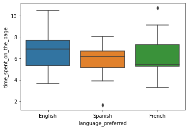

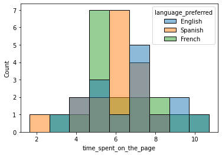

```python
# filter for new page only
new_page_only = df[(df['landing_page']=='new')]

# compare the time spent on the page to the site shown
sns.boxplot(data=new_page_only,x='language_preferred',y='time_spent_on_the_page')
plt.show()

sns.histplot(data=new_page_only, x='time_spent_on_the_page', hue='language_preferred')
plt.show()
```

Observation: It looks like there is a small difference in the median time spent on the page for each of the preferred languages, but possibly the means don't have as much of a difference.

### Step 1: Define the null and alternate hypotheses

Let $\mu_1, \mu_2, \mu_3$ be the means of time spent on the new page for users with preferred languages of english, spanish, and french respectively.

We will test the null hypothesis

> $H_0: \mu_1 = \mu_2 = \mu_3$

against the alternative hypothesis

> $H_a: $ At least one mean time spent on the new page is different from the rest.

### Step 2: Select Appropriate test

We will use a One-way ANOVA Test. One variable is discrete and the other is continuous.

### Step 3: Decide the significance level

We have been told to use a 5% significance level so will set alpha as 0.05

### Step 4: Collect and prepare data

```python
# filter for new page only
new_page_only = df[(df['landing_page']=='new')]

# get the mean of time spent on the new page for
new_page_only.groupby('language_preferred')['time_spent_on_the_page'].mean()
```

```
language_preferred
English    6.663750
French     6.196471
Spanish    5.835294
Name: time_spent_on_the_page, dtype: float64
```

### Step 5: Calculate the p-value

```python
#import the required function
from scipy.stats import f_oneway

# perform one-way anova test
test_stat, p_value = f_oneway(df.loc[df['language_preferred'] == 'English', 'time_spent_on_the_page'],
                              df.loc[df['language_preferred'] == 'French', 'time_spent_on_the_page'],
                              df.loc[df['language_preferred'] == 'Spanish', 'time_spent_on_the_page'])
print('The p-value is ' + str(p_value))
```

```
The p-value is 0.8665610536012648
```

### Step 6: Compare the p-value with $\alpha$

```python
# check to see if p-value is less than alpha
p_value < 0.05
```

```
False
```

Since the p-value is greater than the level of significance (0.05) we cannot reject the null hypothesis.

## Conclusion and Business Recommendations

We found that users who spent more time on the page were more likely to subscribe. We also found that users who saw the new landing page spent more time on the page than users who were shown the old landing page. We then validated that by concluding that users who were shown the new landing page had a higher conversion rate than users shown the old landing page.

The next thing we wanted to check was to see if users with different preferred languages of English, Spanish, & French had an impact on the amount of time they spent on the site and if the preferred language was independent of conversion. We found that there was no statistical difference in the amount of time users with different preferred languages spent on the site, and conversion was not dependent on language preference.

Therefore, it is recommended to implement the new landing page as-is with the same, current functionality in place for users of different preferred languages. With the implementation, E-news Express can expect to see more site visitors subscribing.

```python
# convert to html
%%shell
jupyter nbconvert --to html '/content/drive/MyDrive/Colab Notebooks/PYF_Project_LearnerNotebook_FullCode.ipynb'
```